# P4 - Red Wine Quality - Exploratory Data Analysis by S.Jaeger

### Plot Two

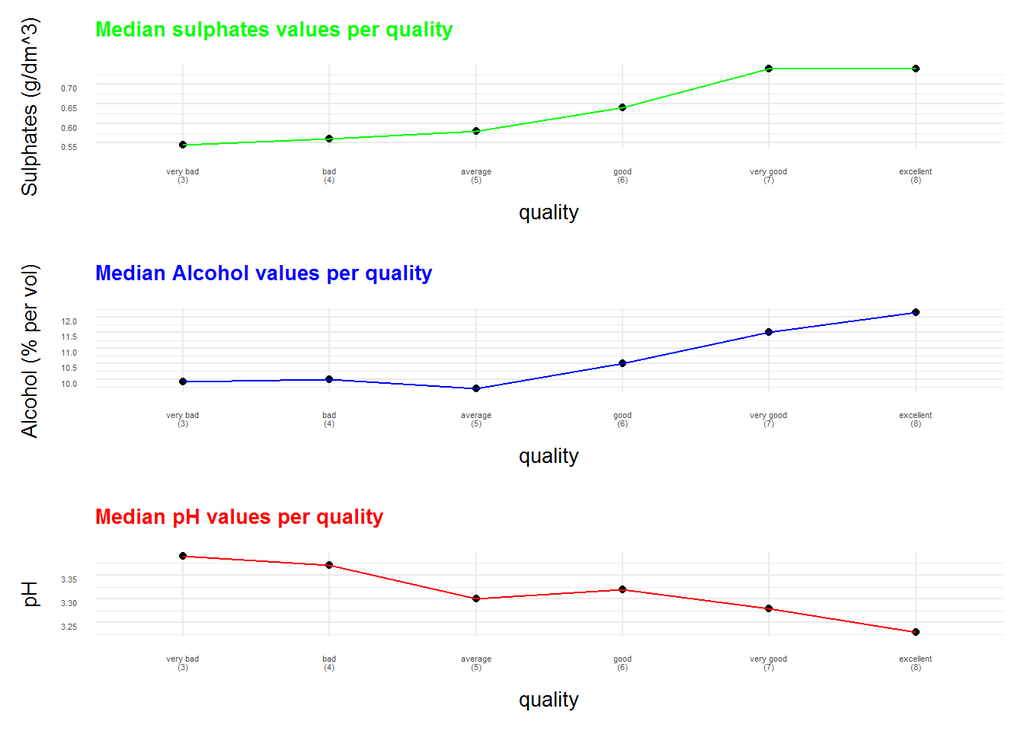

### Description Two

Those line plots are very raw, but their simplicity highlight very well some tendencies: - As the quality increases, the median pH seems to drop. - As the quality increases, the median alcohol seems to increase. - As the quality increases, the median sulphates seem to increase until reaching a plateau.

### Plot Three

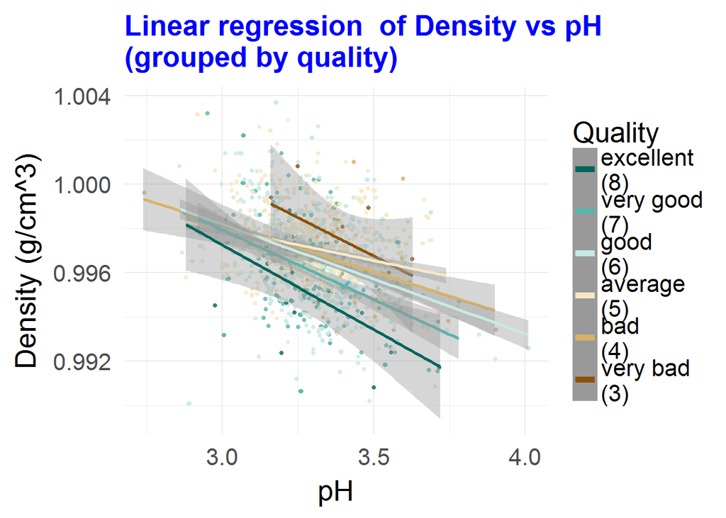

### Description Three

This plot is the most sophisticated one. I like it very much as it compiles many informations in a single place:  
- First you have a scatter plot showing 2D data.  
- Then a third dimension is added thanks to the color of the dots. This enables to see how each quality category is distributed in term of density & pH.  
- Last, but not least, a linear regression is provided for each quality category that summarizes the data and provides the rough trends.  
In the end, the plot is very meaningful, especially when it comes to the two opposite categories that are excellent & very bad red wines. As for those two categories the regression lines are parallel but clearly segregated. This is not so clear for other wine categories unfortunately, especially when ti comes to low pH values.

# Reflection

I liked this assignment as it enabled me to mix two ambivalent feelings:  
- My love of wine.  
- My hate of chemistry.  
I have to admit however that this lack of knowledge in chemistry prevents this analysis to be even more relevant. At some point, some skills in chemistry would have been very useful to interpret all the findings brought by this data exploration.

I also had to struggle to fine tune all the plots. I mean, I find it incredibly quick and efficient to get some plots using R, even the most complex ones. However, styling, forcing colors, controling the text size and the layout of aggregated plots took me a lot more time.

To conclude, if I had a little more time, an interesting thing I would have done, would be to merge the two data sets dealing with Red & White wine, and overlaying the two of them on the same plots (with different colors & alpha) to see how they differ. This would bring nice vizualisation I guess.

**Sources & References:**  
Original assignment from udacity:  
[1] Udacity https://docs.google.com/document/d/1qEcwltBMlRYZT-l699-71TzInWfk4W9q5rTCSvDVMpc/pub?embedded=true  
[2] Official Dataset Description https://s3.amazonaws.com/udacity-hosted-downloads/ud651/wineQualityInfo.txt [3] “Drops of God” wikipedia page https://en.wikipedia.org/wiki/Drops_of_God

[Cortez et al., 2009] P. Cortez, A. Cerdeira, F. Almeida, T. Matos and J. Reis. Modeling wine preferences by data mining from physicochemical properties. In Decision Support Systems, Elsevier, 47(4):547-553. ISSN: 0167-9236. http://dx.doi.org/10.1016/j.dss.2009.05.016

**Revisions:**  
[1] - Friday the 17th of March, original submission  
[2] - Sunday the 19th of March, rework after 1st review